# Chapter 1 - Importing and Visualizing Functional Data

Vanilton Paulo

2025-08-15

This vignette explains the key concepts behind functional data analysis (FDA) using the **`tidyfun`** package, using the COVID-19 U.S mortality dataset.The aim is to show why we make specific choices and what they accomplish. We will follow the Functional Data Analysis with R , and use **`tidyfun`** package to analyze the dataset.The end goal is to produce comprehensive documentation or vignette that not only replicate the analyses but also provide theoretical insights and potential extensions.

Why functional data?

Functional Data Analysis treats data as curves or functions.Each observational unit as a function over a continuum, this could be for example over time and even space. Instead of analyzing separate weekly death counts, we analyze the entire mortality curve over time as a single entity. The weekly mortality data is not simply a collection of numbers.The underlying trend of mortality is a smooth process that is happening continuously, not just in weekly bursts.

# COVID-19 US Mortality Data

#### Weekly all-cause mortality data

We aim to apply functional data analysis methods, implemented via the tidyfun package, to visualize U.S. mortality trends with a focus on the year 2020. The analysis addresses two objectives:

1. To visualize all-cause total and excess mortality(mortality in a week in 2020 minus mortality in the coresponding week in 2019).
2. To visualize the temporal pattern of the total COVID-19 mortality.

```r
# ─ Packages ───────────────────
#List of required packages
packages <- c(
  "refund",
  "tidyverse",
  "tidyfun"
)

#Install missing packages
install_if_missing <- function(pkg) {
  if (!requireNamespace(pkg, quietly = TRUE)) {
    install.packages(pkg)
  }
}

#Install missing packages
invisible(lapply(packages, install_if_missing))



#Load packages
library(refund)
library(tidyverse)
library(tidyfun)

#For reproducible results
set.seed(53615)
```

```r
# ──── Overview ───────────────────
data("COVID19", package = "refund")
names(COVID19)
##  [1] "US_weekly_mort"                      "US_weekly_mort_dates"
##  [3] "US_weekly_mort_CV19"                 "US_weekly_mort_CV19_dates"
##  [5] "US_weekly_excess_mort_2020"          "US_weekly_excess_mort_2020_dates"
##  [7] "US_states_names"                     "US_states_population"
##  [9] "States_excess_mortality"             "States_excess_mortality_per_million"
## [11] "States_CV19_mortality"               "States_CV19_mortality_per_million"
```

```r
# ───────────── helpers ───────────────────
#Converts calendar dates to numeric values
#The tfd requires numeric values and not as dates values.
num_grid <- function(dates, ref = min(dates)) as.numeric(dates - ref)
reference_date <- as.Date("2020-01-01")
```

#### Weekly all-cause mortality in the US

```r
#Obtain weekly all-cause excess mortality between 2017 to end of 2020
counts_state <- COVID19$US_weekly_mort
date_state <- COVID19$US_weekly_mort_dates
```

Visualization of COVID-19 and all-cause mortality

```r
# ─── Data Transformation ─────────────
nat_weekly <- tibble(
  date = date_state,
#The weekly all-cause death counts
#Divide by 1000 to indicate numbers in thousands
  deaths = counts_state / 1000
)


#Shaded regions highlighting 2019 (blue) and 2020 (red)
shade <- nat_weekly %>%
  filter(year(date) %in% c(2019, 2020)) %>%
  mutate(
    year = year(date),
    day_num = num_grid(date, ref = min(nat_weekly$date))
  ) %>%
  group_by(year) %>%
  summarise(
    #For each year, get the min and max week-index
    xmin = min(day_num),
    xmax = max(day_num),
    .groups = "drop"
  ) %>%
  mutate(
    band = as.character(year),
    colour = c("blue", "red")
  )

#X-axis year labels at first week of each year
year_ticks <- nat_weekly %>%
#We add two new columns
  mutate(
    year = year(date),
    day_num = num_grid(date)
  ) %>%
  group_by(year) %>%
  #Within each year, we take the row with the smallest date for the plot
  slice_min(date, n = 1) %>%
  ungroup()
```

`tfd` object represent mortality trajectories as continuous curve.It enables interpolation between observed weeks.Using interpolation, more specifically `tf_approx_linear`, turns weekly counts into approximated functions.`tfd` treats the entire time series as a single functional observation and allows functional operations and analysis methods.

```r
# ────────── Turn into tfd ─────────────
nat_weekly_tfd <- tfd(
#We reshape the deaths into a 1-row matrix so it’s  one curve through 2017 to 2020.
  matrix(nat_weekly$deaths, nrow = 1),
  arg = num_grid(nat_weekly$date)
)
# tfd[1] on (0,1442) based on 207 evaluations each
# interpolation by tf_approx_linear
# [1]: ( 0,61);( 7,59);(14,58); ..
```

The `geom_meatballs` its designed specifically for spaghetti plots with points for functional data objects

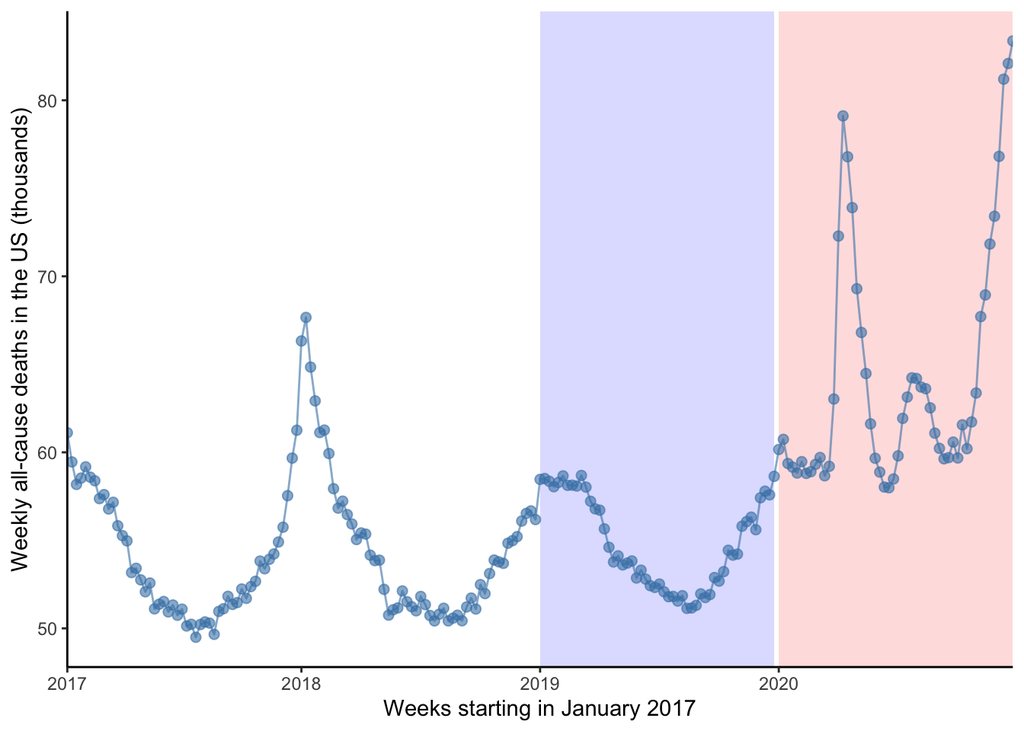

```r
# ─────────────────── Plot ─────────────

ggplot() +
  geom_rect(
    data = shade,
    aes(xmin = xmin, xmax = xmax, ymin = -Inf, ymax = Inf, fill = colour),
    inherit.aes = FALSE, alpha = 0.15
  ) +
  scale_fill_identity() +
  geom_meatballs(
    data = tibble(y = nat_weekly_tfd),
    aes(y = y),
    colour = "steelblue", size = 2, alpha = 0.6
  ) +
  scale_x_continuous(
    breaks = year_ticks$day_num,
    labels = year_ticks$year,
    expand = c(0, 0)
  ) +
  labs(
    x = "Weeks starting in January 2017",
    y = "Weekly all-cause deaths in the US (thousands)"
  ) +
  theme_classic()
```

FIGURE 1.1: The weekly death counts in the United States from 14 of January 2017 to 26 of December 2020. Each point corresponds to a single week, with deaths reported in thousands. For instance, in the week of 5 May 2018 , there were 53,874 deaths nationwide.

#### Weekly US COVID-19 mortality data

```r
# ─── Data ──────────────────
#Obtain covid-19 associated deaths in the US
cv19_deaths <- COVID19$US_weekly_mort_CV19
week_diff <- COVID19$US_weekly_excess_mort_2020
current_date <- COVID19$US_weekly_excess_mort_2020_dates
```

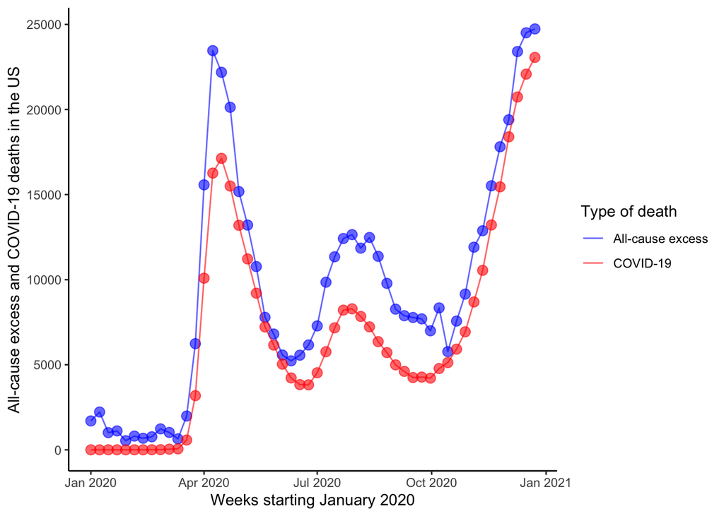

```r
# ─── Turn into tfd ──────────────────

death_tf <- tfd(
  rbind(week_diff, cv19_deaths),
  arg = num_grid(current_date)
)
# tfd[2] on (0,357) based on 52 evaluations each
# interpolation by tf_approx_linear
# week_diff: ( 0,1698);( 7,2222);(14,1011); ...
# cv19_deaths: ( 0,   0);( 7,   0);(14,   3); ...

# ── Prepare data for plotting ──────────────────

excess_tibble <- tibble(
  death_type = c("All-cause excess", "COVID-19"),
  curve = death_tf
)
# A tibble: 2 × 2
#   death_type                                         curve
#   <chr>                                          <tfd_reg>
# 1 All-cause excess [1]: ( 0,1698);( 7,2222);(14,1011); ...
# 2 COVID-19         [2]: ( 0,   0);( 7,   0);(14,   3); ...


# ──────────────── Plot ────────────────
ggplot(excess_tibble, aes(y = curve, colour = death_type)) +
  geom_meatballs(size = 3, alpha = 0.6) +
  scale_colour_manual(values = c("blue", "red")) +
  scale_x_continuous(
    name = "Weeks starting January 2020",
    breaks = as.numeric(seq(reference_date, as.Date("2021-01-01"), by = "3 months") - reference_date),
    labels = format(seq(reference_date, as.Date("2021-01-01"), by = "3 months"), "%b %Y")
  ) +
  labs(
    x = "Weeks starting in January 2020",
    y = "All-cause excess and COVID-19 deaths in the US",
  color = "Type of death"
  ) +
  theme_classic()
```

FIGURE 1.2: The total weekly U.S. mortality caused by COVID-19 alongside estimated excess deaths.The blue points represent excess mortality, calculated as the difference between the total deaths in a given week of 2020 and the corresponding week in 2019. The red points indicate the number of deaths each week directly caused by COVID-19.

Total excess deaths before the week ending on 26 december 2020.

```r
cumsum(death_tf$week_diff)[52]
```

```
## [1] 496204
```

COVID-19 deaths before the week ending on on 26 december 2020.

```r
cumsum(death_tf$cv19_deaths)[52]
```

```
## [1] 365122
```

There are 35.9% more excess deaths than COVID-19 deaths in this timeframe.

#### Plot of all-cause cumulative excess data

Plot the all-cause US excess mortality data for year 2020.

```r
# ── Data ───────────────────
new_states <- COVID19$US_states_names
state_population <- COVID19$US_states_population
states_excess <- COVID19$States_excess_mortality
```

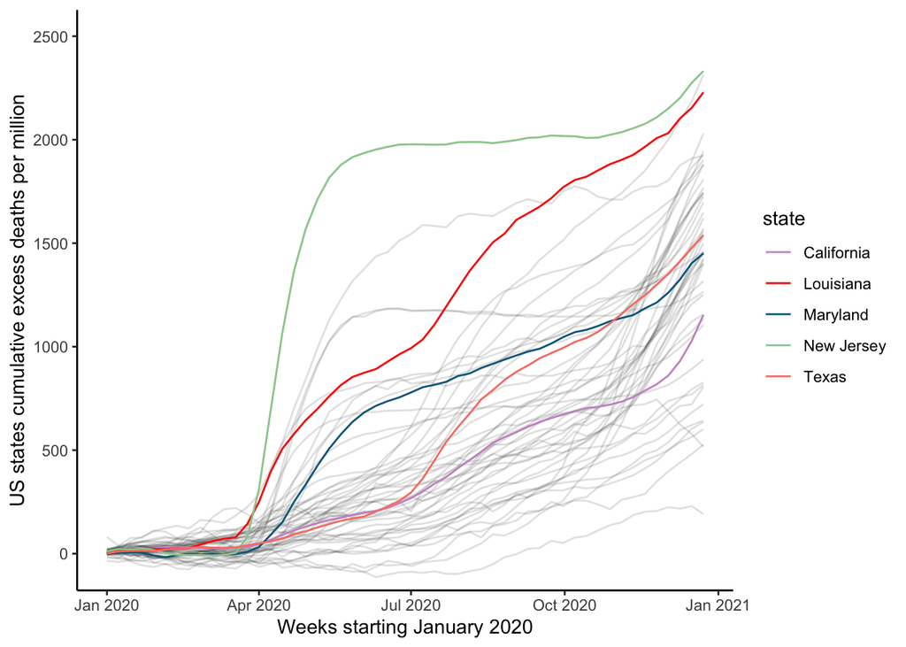

```r
# ── Data Transformation ───────────────────

#Normalize to rate per 1 million people
rate_mat <- sweep(states_excess, 1, state_population / 1e6, "/")
#Row by row , and replace each row with its cumulative sum.
#We transpose it back so that rows = states, columns = weeks again.
cum_mat <- t(apply(rate_mat, 1, cumsum))

# ────────────── Turn into tfd ──────────────────

#Thus tfd object, a data structure where each functional curve represents a distinct state.
state_tf <- tfd(cum_mat, arg = num_grid(current_date))
# tfd[52] on (0,357) based on 52 evaluations each
# interpolation by tf_approx_linear
# [1]: ( 0, 0.8);( 7, 8.3);(14,-6.9); ...
# [2]: ( 0,  -5);( 7,  19);(14,  26); ...
# [3]: ( 0,  -7);( 7,  -1);(14,   5); ...
# [4]: ( 0,  -7);( 7,  21);(14,  20); ...
# [5]: ( 0,   5);( 7,   7);(14,  12); ...
#     [....]   (47 not shown)


# ── Prepare data for plotting ──────────────────

state_df <- tibble(
  state = new_states,
  curve = state_tf
)

# A tibble: 52 × 2
#    state                                                   curve
#    <chr>                                               <tfd_reg>
#  1 Alabama               [1]: ( 0, 0.8);( 7, 8.3);(14,-6.9); ...
#  2 Alaska                [2]: ( 0,  -5);( 7,  19);(14,  26); ...
#  3 Arizona               [3]: ( 0,  -7);( 7,  -1);(14,   5); ...
#  4 Arkansas              [4]: ( 0,  -7);( 7,  21);(14,  20); ...
#  5 California            [5]: ( 0,   5);( 7,   7);(14,  12); ...
#  6 Colorado              [6]: ( 0,   3);( 7,  10);(14,  14); ...
#  7 Connecticut           [7]: ( 0, 0.3);( 7, 1.1);(14, 4.2); ...
#  8 Delaware              [8]: ( 0,  14);( 7,  13);(14,   4); ...
#  9 District of Columbia  [9]: ( 0,   3);( 7,  11);(14,  60); ...
# 10 Florida              [10]: ( 0,   6);( 7,  15);(14,  24); ...
# ℹ 42 more rows

# ── Plot ────────────────

#Emphasized states
emph_states <- c("New Jersey", "Louisiana", "California", "Maryland", "Texas")
emph_cols <- c("darkseagreen3", "red", "plum3", "deepskyblue4", "salmon")

ggplot() +
  geom_spaghetti(
    data = state_df,
    aes(y = curve),
    colour = "grey20", alpha = .15
  ) +
  geom_spaghetti(
    data   = filter(state_df, state %in% emph_states),
    aes(y = curve, colour = state), alpha = 5
  ) +
  scale_colour_manual(values = setNames(emph_cols, emph_states)) +
  scale_x_continuous(
    name = "Weeks starting January 2020",
    breaks = as.numeric(seq(reference_date, as.Date("2021-01-01"), by = "3 months") - reference_date),
    labels = format(seq(reference_date, as.Date("2021-01-01"), by = "3 months"), "%b %Y")
  ) +
  coord_cartesian(ylim = c(-50, 2500)) +
  labs(
    x = "Weeks starting January 2020",
    y = "US states cumulative excess deaths per million"
  ) +
  theme_classic() +
  theme(legend.position = "right")
```

FIGURE 1.3: Each U.S. state,the lines track the cumulative weekly all-cause excess mortality per million for each U.S. state. Five states receive special focus and are distinguished by color: New Jersey (green), Louisiana (red), California (plum),Maryland (blue) and Texas (salmon).All remaining states are in grey including Puerto Rico and District of Colombia.

#### Plot of COVID-19 cumulative data

```r
# ── Data ────────────
states_CV19_mort <- COVID19$States_CV19_mortality
```

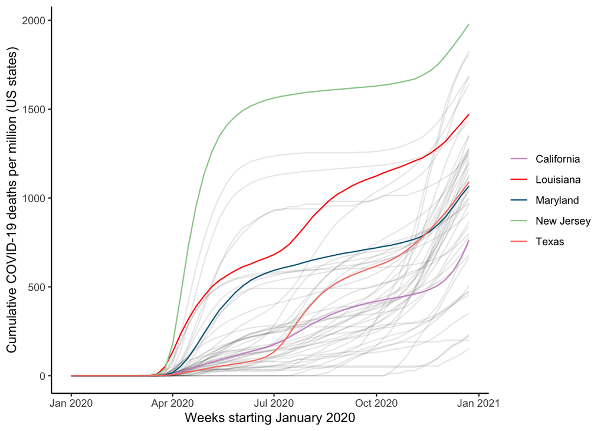

```r
# ── Data Transformation ───────────────────
per_mil_mat <- sweep(states_CV19_mort, 1, state_population / 1e6, "/")
cum_covid <- t(apply(per_mil_mat, 1, function(x) cumsum(replace_na(x, 0))))

# ────────────── Turn into tfd ──────────────────

covid_tf <- tfd(cum_covid, arg = num_grid(current_date))
# tfd[52] on (0,357) based on 52 evaluations each
# interpolation by tf_approx_linear
# [1]: ( 0,0);( 7,0);(14,0); ...
# [2]: ( 0,0);( 7,0);(14,0); ...
# [3]: ( 0,0);( 7,0);(14,0); ...
# [4]: ( 0,0);( 7,0);(14,0); ...
# [5]: ( 0,0);( 7,0);(14,0); ...
#     [....]   (47 not shown)

# ── Data Transformation ───────────────────
covid_df <- tibble(
  state = new_states,
  curve = covid_tf
)
# A tibble: 52 × 2
#    state                                          curve
#    <chr>                                      <tfd_reg>
#  1 Alabama               [1]: ( 0,0);( 7,0);(14,0); ...
#  2 Alaska                [2]: ( 0,0);( 7,0);(14,0); ...
#  3 Arizona               [3]: ( 0,0);( 7,0);(14,0); ...
#  4 Arkansas              [4]: ( 0,0);( 7,0);(14,0); ...
#  5 California            [5]: ( 0,0);( 7,0);(14,0); ...
#  6 Colorado              [6]: ( 0,0);( 7,0);(14,0); ...
#  7 Connecticut           [7]: ( 0,0);( 7,0);(14,0); ...
#  8 Delaware              [8]: ( 0,0);( 7,0);(14,0); ...
#  9 District of Columbia  [9]: ( 0,0);( 7,0);(14,0); ...
# 10 Florida              [10]: ( 0,0);( 7,0);(14,0); ...
# ℹ 42 more rows

# ─────────── Plot ────────────────
#Plot of COVID-19 cumulative data

ggplot() +
  geom_spaghetti(
    data = covid_df,
    aes(y = curve),
    colour = "black", alpha = 0.1
  ) +
  # highlighted states
  geom_spaghetti(
    data   = filter(covid_df, state %in% emph_states),
    aes(y = curve, colour = state), alpha = 2
  ) +
  scale_colour_manual(values = setNames(emph_cols, emph_states)) +
  scale_x_continuous(
    name = "Weeks starting January 2020",
    breaks = as.numeric(seq(reference_date, as.Date("2021-01-01"), by = "3 months") - reference_date),
    labels = format(seq(reference_date, as.Date("2021-01-01"), by = "3 months"), "%b %Y")
  ) +
  coord_cartesian(ylim = c(0, NA)) +
  labs(
    x = "Weeks starting January 2020",
    y = "Cumulative COVID-19 deaths per million (US states)",
    col = NULL
  ) +
  theme_classic() +
  theme(legend.position = "right")
```

FIGURE 1.4: Each U.S. state,the lines track the cumulative COVID-19 mortality for each U.S. state. Five states receive special focus and are distinguished by color: New Jersey (green), Louisiana (red), California (plum),Maryland (blue) and Texas (salmon).All remaining states are in grey including Puerto Rico and District of Colombia.